# Practical 2 (Fundamental Techniques in Data Science with R)

Amanda Ferraboli

2023-11-20

### Importing Packages

```r
library(tidyverse)
library(kableExtra)
```

### Preparation

Loading Data: General Social Survey

```r
gss_cat <- forcats::gss_cat
head(gss_cat)
```

```
## # A tibble: 6 × 9
##    year marital         age race  rincome        partyid     relig denom tvhours
##   <int> <fct>         <int> <fct> <fct>          <fct>       <fct> <fct>   <int>
## 1  2000 Never married    26 White $8000 to 9999  Ind,near r… Prot… Sout…      12
## 2  2000 Divorced         48 White $8000 to 9999  Not str re… Prot… Bapt…      NA
## 3  2000 Widowed          67 White Not applicable Independent Prot… No d…       2
## 4  2000 Never married    39 White Not applicable Ind,near r… Orth… Not …       4
## 5  2000 Divorced         25 White Not applicable Not str de… None  Not …       1
## 6  2000 Married          25 White $20000 - 24999 Strong dem… Prot… Sout…      NA
```

```r
# check variable classes
str(gss_cat)
```

```
## tibble [21,483 × 9] (S3: tbl_df/tbl/data.frame)
##  $ year   : int [1:21483] 2000 2000 2000 2000 2000 2000 2000 2000 2000 2000 ...
##  $ marital: Factor w/ 6 levels "No answer","Never married",..: 2 4 5 2 4 6 2 4 6 6 ...
##  $ age    : int [1:21483] 26 48 67 39 25 25 36 44 44 47 ...
##  $ race   : Factor w/ 4 levels "Other","Black",..: 3 3 3 3 3 3 3 3 3 3 ...
##  $ rincome: Factor w/ 16 levels "No answer","Don't know",..: 8 8 16 16 16 5 4 9 4 4 ...
##  $ partyid: Factor w/ 10 levels "No answer","Don't know",..: 6 5 7 6 9 10 5 8 9 4 ...
##  $ relig  : Factor w/ 16 levels "No answer","Don't know",..: 15 15 15 6 12 15 5 15 15 15 ...
##  $ denom  : Factor w/ 30 levels "No answer","Don't know",..: 25 23 3 30 30 25 30 15 4 25 ...
##  $ tvhours: int [1:21483] 12 NA 2 4 1 NA 3 NA 0 3 ...
```

### Tibbles

```r
as_tibble(gss_cat)
```

```
## # A tibble: 21,483 × 9
##     year marital         age race  rincome        partyid    relig denom tvhours
##    <int> <fct>         <int> <fct> <fct>          <fct>      <fct> <fct>   <int>
##  1  2000 Never married    26 White $8000 to 9999  Ind,near … Prot… Sout…      12
##  2  2000 Divorced         48 White $8000 to 9999  Not str r… Prot… Bapt…      NA
##  3  2000 Widowed          67 White Not applicable Independe… Prot… No d…       2
##  4  2000 Never married    39 White Not applicable Ind,near … Orth… Not …       4
##  5  2000 Divorced         25 White Not applicable Not str d… None  Not …       1
##  6  2000 Married          25 White $20000 - 24999 Strong de… Prot… Sout…      NA
##  7  2000 Never married    36 White $25000 or more Not str r… Chri… Not …       3
##  8  2000 Divorced         44 White $7000 to 7999  Ind,near … Prot… Luth…      NA
##  9  2000 Married          44 White $25000 or more Not str d… Prot… Other       0
## 10  2000 Married          47 White $25000 or more Strong re… Prot… Sout…       3
## # ℹ 21,473 more rows
```

### Working with pipes

```r
gss_cat %>%
  filter(relig == "Protestant") %>%
  group_by(year, relig) %>%
  summarize(tvhours = mean(tvhours, na.rm = TRUE))
```

```
## # A tibble: 8 × 3
## # Groups:   year [8]
##    year relig      tvhours
##   <int> <fct>        <dbl>
## 1  2000 Protestant    3.16
## 2  2002 Protestant    3.02
## 3  2004 Protestant    2.91
## 4  2006 Protestant    3.06
## 5  2008 Protestant    3.23
## 6  2010 Protestant    3.15
## 7  2012 Protestant    3.44
## 8  2014 Protestant    3.15
```

```r
# less readable
summarize(group_by(filter(gss_cat,
                          relig == "Protestant"),
                   year,
                   relig),
          tvhours = mean(tvhours,
                         na.rm = TRUE)
          )
```

```
## # A tibble: 8 × 3
## # Groups:   year [8]
##    year relig      tvhours
##   <int> <fct>        <dbl>
## 1  2000 Protestant    3.16
## 2  2002 Protestant    3.02
## 3  2004 Protestant    2.91
## 4  2006 Protestant    3.06
## 5  2008 Protestant    3.23
## 6  2010 Protestant    3.15
## 7  2012 Protestant    3.44
## 8  2014 Protestant    3.15
```

### Missing values

#### Standard missing values

```r
gss_cat[1:10,] %>%
  kable() %>%
  kable_styling(latex_options = "striped")
```

| year | marital | age | race | rincome | partyid | relig | denom | tvhours |
| --- | --- | --- | --- | --- | --- | --- | --- | --- |
| 2000 | Never married | 26 | White | $8000 to 9999 | Ind,near rep | Protestant | Southern baptist | 12 |
| 2000 | Divorced | 48 | White | $8000 to 9999 | Not str republican | Protestant | Baptist-dk which | NA |
| 2000 | Widowed | 67 | White | Not applicable | Independent | Protestant | No denomination | 2 |
| 2000 | Never married | 39 | White | Not applicable | Ind,near rep | Orthodox-christian | Not applicable | 4 |
| 2000 | Divorced | 25 | White | Not applicable | Not str democrat | None | Not applicable | 1 |
| 2000 | Married | 25 | White | $20000 - 24999 | Strong democrat | Protestant | Southern baptist | NA |
| 2000 | Never married | 36 | White | $25000 or more | Not str republican | Christian | Not applicable | 3 |
| 2000 | Divorced | 44 | White | $7000 to 7999 | Ind,near dem | Protestant | Lutheran-mo synod | NA |
| 2000 | Married | 44 | White | $25000 or more | Not str democrat | Protestant | Other | 0 |
| 2000 | Married | 47 | White | $25000 or more | Strong republican | Protestant | Southern baptist | 3 |

```r
anyNA(gss_cat)
```

```
## [1] TRUE
```

```r
# Exercise 1. Using is.na() which variable has only standard missing values (NAs)
is.na(gss_cat)
```

[output not shown]

[output cut: 11098 more lines]

```r
# To tell which variable has standard missing values, using the is.na() function, we should pass the data object (gss_cat) as the argument of is.na() and look for where "TRUE" is returned columnwise.
# The column 'tvhours' has standard missing values (NAs).

# finding-standard-missings-quicker
gss_cat %>%
  select(everything()) %>%
  summarise_all(funs(sum(is.na(.))))
```

```
## # A tibble: 1 × 9
##    year marital   age  race rincome partyid relig denom tvhours
##   <int>   <int> <int> <int>   <int>   <int> <int> <int>   <int>
## 1     0       0    76     0       0       0     0     0   10146
```

```r
# easier to find out with the sum per column that 'age' also has NAs.
```

#### Non-standard missing values

```r
gss_cat %>%
  count(rincome)
```

```
## # A tibble: 16 × 2
##    rincome            n
##    <fct>          <int>
##  1 No answer        183
##  2 Don't know       267
##  3 Refused          975
##  4 $25000 or more  7363
##  5 $20000 - 24999  1283
##  6 $15000 - 19999  1048
##  7 $10000 - 14999  1168
##  8 $8000 to 9999    340
##  9 $7000 to 7999    188
## 10 $6000 to 6999    215
## 11 $5000 to 5999    227
## 12 $4000 to 4999    226
## 13 $3000 to 3999    276
## 14 $1000 to 2999    395
## 15 Lt $1000         286
## 16 Not applicable  7043
```

```r
# "No answer", "Don't know", "Refused" and "Not applicable" are responses that can be considered missing values depending on the context.

# Exercise 2. Are there similar responses in the other factor variables? Which ones?

gss_cat %>%
  count(marital) # 'marital' has "No answer", which can be considered missing.
```

```
## # A tibble: 6 × 2
##   marital           n
##   <fct>         <int>
## 1 No answer        17
## 2 Never married  5416
## 3 Separated       743
## 4 Divorced       3383
## 5 Widowed        1807
## 6 Married       10117
```

```r
gss_cat %>%
  count(race) # 'race' has 3 types of answers, "Black", "White" and "Other", none would be considered missing.
```

```
## # A tibble: 3 × 2
##   race      n
##   <fct> <int>
## 1 Other  1959
## 2 Black  3129
## 3 White 16395
```

```r
gss_cat %>%
  count(partyid) # 'partyid' has "No answer" and "Don't know", which can be considered missing.
```

```
## # A tibble: 10 × 2
##    partyid                n
##    <fct>              <int>
##  1 No answer            154
##  2 Don't know             1
##  3 Other party          393
##  4 Strong republican   2314
##  5 Not str republican  3032
##  6 Ind,near rep        1791
##  7 Independent         4119
##  8 Ind,near dem        2499
##  9 Not str democrat    3690
## 10 Strong democrat     3490
```

```r
gss_cat %>%
  count(relig) # 'relig' has "No answer" and "Don't know", which can be considered missing. Even if the respondent does not have a religion, there is a category "None" for those cases, so "No answer" is really missing.
```

```
## # A tibble: 15 × 2
##    relig                       n
##    <fct>                   <int>
##  1 No answer                  93
##  2 Don't know                 15
##  3 Inter-nondenominational   109
##  4 Native american            23
##  5 Christian                 689
##  6 Orthodox-christian         95
##  7 Moslem/islam              104
##  8 Other eastern              32
##  9 Hinduism                   71
## 10 Buddhism                  147
## 11 Other                     224
## 12 None                     3523
## 13 Jewish                    388
## 14 Catholic                 5124
## 15 Protestant              10846
```

```r
gss_cat %>%
  count(denom) # 'denom' has "No answer", "Don't know" and "Not applicable", which can be considered missing.
```

```
## # A tibble: 30 × 2
##    denom                    n
##    <fct>                <int>
##  1 No answer              117
##  2 Don't know              52
##  3 No denomination       1683
##  4 Other                 2534
##  5 Episcopal              397
##  6 Presbyterian-dk wh     244
##  7 Presbyterian, merged    67
##  8 Other presbyterian      47
##  9 United pres ch in us   110
## 10 Presbyterian c in us   104
## # ℹ 20 more rows
```

### Data transformation

#### Filtering data

```r
# Exercise 3 - display only married people

filter(gss_cat, marital == 'Married')
```

```
## # A tibble: 10,117 × 9
##     year marital   age race  rincome        partyid          relig denom tvhours
##    <int> <fct>   <int> <fct> <fct>          <fct>            <fct> <fct>   <int>
##  1  2000 Married    25 White $20000 - 24999 Strong democrat  Prot… Sout…      NA
##  2  2000 Married    44 White $25000 or more Not str democrat Prot… Other       0
##  3  2000 Married    47 White $25000 or more Strong republic… Prot… Sout…       3
##  4  2000 Married    53 White $25000 or more Not str democrat Prot… Other       2
##  5  2000 Married    52 White $25000 or more Ind,near rep     None  Not …      NA
##  6  2000 Married    52 White $25000 or more Strong democrat  Prot… Sout…       1
##  7  2000 Married    51 White $25000 or more Strong republic… Prot… Unit…      NA
##  8  2000 Married    40 Black $25000 or more Strong democrat  Prot… Bapt…       7
##  9  2000 Married    40 White $10000 - 14999 Not str democrat Cath… Not …       3
## 10  2000 Married    45 Black Not applicable Independent      Prot… Unit…      NA
## # ℹ 10,107 more rows
```

```r
# using the pipe operator - steps are more readable
gss_cat %>%
  filter(marital == "Married")
```

```
## # A tibble: 10,117 × 9
##     year marital   age race  rincome        partyid          relig denom tvhours
##    <int> <fct>   <int> <fct> <fct>          <fct>            <fct> <fct>   <int>
##  1  2000 Married    25 White $20000 - 24999 Strong democrat  Prot… Sout…      NA
##  2  2000 Married    44 White $25000 or more Not str democrat Prot… Other       0
##  3  2000 Married    47 White $25000 or more Strong republic… Prot… Sout…       3
##  4  2000 Married    53 White $25000 or more Not str democrat Prot… Other       2
##  5  2000 Married    52 White $25000 or more Ind,near rep     None  Not …      NA
##  6  2000 Married    52 White $25000 or more Strong democrat  Prot… Sout…       1
##  7  2000 Married    51 White $25000 or more Strong republic… Prot… Unit…      NA
##  8  2000 Married    40 Black $25000 or more Strong democrat  Prot… Bapt…       7
##  9  2000 Married    40 White $10000 - 14999 Not str democrat Cath… Not …       3
## 10  2000 Married    45 Black Not applicable Independent      Prot… Unit…      NA
## # ℹ 10,107 more rows
```

```r
# Exercise 4 - display divorced and widowed people

# the question mentions divorced AND widowed people, but the argument translates to an OR (|) condition since a single person cannot be divorced and widowed at the same time on the data set, and the intention is actually to display both groups.

filter(gss_cat, marital == "Divorced" | marital == "Widowed")
```

```
## # A tibble: 5,190 × 9
##     year marital    age race  rincome        partyid         relig denom tvhours
##    <int> <fct>    <int> <fct> <fct>          <fct>           <fct> <fct>   <int>
##  1  2000 Divorced    48 White $8000 to 9999  Not str republ… Prot… Bapt…      NA
##  2  2000 Widowed     67 White Not applicable Independent     Prot… No d…       2
##  3  2000 Divorced    25 White Not applicable Not str democr… None  Not …       1
##  4  2000 Divorced    44 White $7000 to 7999  Ind,near dem    Prot… Luth…      NA
##  5  2000 Divorced    52 White $25000 or more Ind,near dem    None  Not …       1
##  6  2000 Widowed     77 White Not applicable Strong republi… Jewi… Not …      NA
##  7  2000 Widowed     54 White $25000 or more Ind,near rep    Chri… Not …       1
##  8  2000 Widowed     82 White Not applicable Not str democr… Prot… Other       3
##  9  2000 Widowed     83 White Not applicable Strong democrat Prot… Epis…      NA
## 10  2000 Widowed     89 White Not applicable Not str democr… Prot… Othe…       4
## # ℹ 5,180 more rows
```

```r
gss_cat %>%
  filter(marital == "Divorced" | marital == "Widowed")
```

```
## # A tibble: 5,190 × 9
##     year marital    age race  rincome        partyid         relig denom tvhours
##    <int> <fct>    <int> <fct> <fct>          <fct>           <fct> <fct>   <int>
##  1  2000 Divorced    48 White $8000 to 9999  Not str republ… Prot… Bapt…      NA
##  2  2000 Widowed     67 White Not applicable Independent     Prot… No d…       2
##  3  2000 Divorced    25 White Not applicable Not str democr… None  Not …       1
##  4  2000 Divorced    44 White $7000 to 7999  Ind,near dem    Prot… Luth…      NA
##  5  2000 Divorced    52 White $25000 or more Ind,near dem    None  Not …       1
##  6  2000 Widowed     77 White Not applicable Strong republi… Jewi… Not …      NA
##  7  2000 Widowed     54 White $25000 or more Ind,near rep    Chri… Not …       1
##  8  2000 Widowed     82 White Not applicable Not str democr… Prot… Other       3
##  9  2000 Widowed     83 White Not applicable Strong democrat Prot… Epis…      NA
## 10  2000 Widowed     89 White Not applicable Not str democr… Prot… Othe…       4
## # ℹ 5,180 more rows
```

#### Arranging data

```r
# Exercise 5 - reorder the information in the dataframe by the number of tv hours

gss_cat %>%
  arrange(tvhours)
```

```
## # A tibble: 21,483 × 9
##     year marital         age race  rincome        partyid    relig denom tvhours
##    <int> <fct>         <int> <fct> <fct>          <fct>      <fct> <fct>   <int>
##  1  2000 Married          44 White $25000 or more Not str d… Prot… Other       0
##  2  2000 Never married    23 White $1000 to 2999  Strong de… Prot… Other       0
##  3  2000 Never married    32 White $25000 or more Not str r… Cath… Not …       0
##  4  2000 Divorced         39 White Refused        Independe… None  Not …       0
##  5  2000 Separated        57 Black Not applicable Ind,near … None  Not …       0
##  6  2000 Widowed          78 White Not applicable Not str r… Prot… Unit…       0
##  7  2000 Married          45 Other Refused        Independe… None  Not …       0
##  8  2000 Never married    28 White $25000 or more Other par… Prot… No d…       0
##  9  2000 Widowed          65 White $6000 to 6999  Strong de… Cath… Not …       0
## 10  2000 Never married    34 Black $10000 - 14999 Not str d… None  Not …       0
## # ℹ 21,473 more rows
```

```r
# the default of arrange() function is to use the ascending order, if the descending order was needed, the variable could be passed as argument of function desc(): gss_cat %>% arrange(desc(tvhours))

# Exercise 6 - combine arrange() with function desc() to re-order column in descending order
gss_cat %>%
  arrange(desc(tvhours))
```

```
## # A tibble: 21,483 × 9
##     year marital         age race  rincome        partyid    relig denom tvhours
##    <int> <fct>         <int> <fct> <fct>          <fct>      <fct> <fct>   <int>
##  1  2000 Never married    30 Black Not applicable Independe… Prot… Bapt…      24
##  2  2000 Separated        45 Black Not applicable Ind,near … Prot… Other      24
##  3  2002 Never married    33 White $6000 to 6999  Independe… Cath… Not …      24
##  4  2006 Divorced         53 Black Not applicable Strong de… Prot… Sout…      24
##  5  2008 Divorced         50 Black No answer      Ind,near … Prot… Bapt…      24
##  6  2008 Never married    44 White Not applicable Independe… Prot… Other      24
##  7  2008 Never married    21 White Don't know     Independe… Cath… Not …      24
##  8  2008 Widowed          71 White Not applicable Strong de… Prot… Don'…      24
##  9  2010 Widowed          62 Black Not applicable Strong de… Prot… Am b…      24
## 10  2010 Widowed          52 Black Refused        Strong de… Prot… Bapt…      24
## # ℹ 21,473 more rows
```

```r
# Exercise 7 - filter only married people and arrange them by how much tv they watch

gss_cat %>%
  filter(marital == "Married") %>%
  arrange(tvhours)
```

```
## # A tibble: 10,117 × 9
##     year marital   age race  rincome        partyid          relig denom tvhours
##    <int> <fct>   <int> <fct> <fct>          <fct>            <fct> <fct>   <int>
##  1  2000 Married    44 White $25000 or more Not str democrat Prot… Other       0
##  2  2000 Married    45 Other Refused        Independent      None  Not …       0
##  3  2000 Married    35 White Refused        Strong republic… Prot… Other       0
##  4  2000 Married    38 White $20000 - 24999 Ind,near dem     Cath… Not …       0
##  5  2000 Married    25 White $15000 - 19999 Strong republic… Prot… No d…       0
##  6  2000 Married    48 White $25000 or more Ind,near dem     Prot… Other       0
##  7  2000 Married    37 White $25000 or more Not str democrat Prot… Unit…       0
##  8  2000 Married    39 White Lt $1000       Not str democrat Prot… Othe…       0
##  9  2000 Married    49 White $20000 - 24999 Independent      Prot… No d…       0
## 10  2000 Married    33 White $1000 to 2999  Not str democrat Prot… Other       0
## # ℹ 10,107 more rows
```

```r
# Exercise 8 - use arrange() and count() to find what the most common religion is

gss_cat %>%
  count(relig) %>% # counts the number of occurrence of each religion under generated column 'n'
  arrange(desc(n)) # sorts the occurrences in descending order to find the greatest (most common)
```

```
## # A tibble: 15 × 2
##    relig                       n
##    <fct>                   <int>
##  1 Protestant              10846
##  2 Catholic                 5124
##  3 None                     3523
##  4 Christian                 689
##  5 Jewish                    388
##  6 Other                     224
##  7 Buddhism                  147
##  8 Inter-nondenominational   109
##  9 Moslem/islam              104
## 10 Orthodox-christian         95
## 11 No answer                  93
## 12 Hinduism                   71
## 13 Other eastern              32
## 14 Native american            23
## 15 Don't know                 15
```

```r
# good example showing the usefulness of pipes performing more than one operation
```

#### Summarizing data

```r
# Exercise 9 - How many hours of tv on average are watched by people of different religions?

gss_cat %>%
  group_by(relig) %>%
  summarise(avg_tvhours = mean(tvhours, na.rm = TRUE))
```

```
## # A tibble: 15 × 2
##    relig                   avg_tvhours
##    <fct>                         <dbl>
##  1 No answer                      2.72
##  2 Don't know                     4.62
##  3 Inter-nondenominational        2.87
##  4 Native american                3.46
##  5 Christian                      2.79
##  6 Orthodox-christian             2.42
##  7 Moslem/islam                   2.44
##  8 Other eastern                  1.67
##  9 Hinduism                       1.89
## 10 Buddhism                       2.38
## 11 Other                          2.73
## 12 None                           2.71
## 13 Jewish                         2.52
## 14 Catholic                       2.96
## 15 Protestant                     3.15
```

```r
# If there are any missing values in the group, the mean function returns NA. 'na.rm = TRUE', which means remove the NA values, can be used to drop the missing values and return the expected average by different religions.
```

### Strings

```r
# String Concatenation

# Exercise 10 - difference between the two commands
str_c("x", "y", "z")
```

```
## [1] "xyz"
```

```r
str_c("x", "y", "z", sep = ", ")
```

```
## [1] "x, y, z"
```

```r
# the argument 'sep' separates each letter in the string, in this case, by a comma. The default is no separator (sep = ""), seen on the fisrt command.


# Subsetting strings
x <- c("Apple", "Banana", "Pear")
str_sub(x, 1, 3) # extracts from 1st ('start') to 3rd ('end') character
```

```
## [1] "App" "Ban" "Pea"
```

```r
# Regular expressions
x <- c("apple", "banana", "pear")
str_view(x, "an")
```

```
## [2] │ b<an><an>a
```

```r
str_view(x, ".a.") # only one match in banana since the second 'a' does not match the condition, because the n (3rd charcater) was already 'taken'.
```

```
## [2] │ <ban>ana
## [3] │ p<ear>
```

```r
# Anchors
#matching the start (^) and end ($) of strings
x <- c("apple", "banana", "pear")

str_view(x, "^a")
```

```
## [1] │ <a>pple
```

```r
str_view(x, "a$")
```

```
## [2] │ banan<a>
```

```r
x <- c("apple pie", "apple", "apple cake")

str_view(x, "^apple$")
```

```
## [2] │ <apple>
```

### Factors

#### Modifying factor order

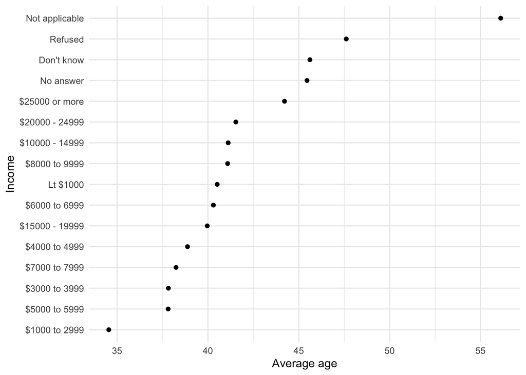

```r
# Exercise 11 - average age across income levels
rincome_summary <- gss_cat %>%
  group_by(rincome) %>%
  summarise(
    age = mean(age, na.rm = TRUE),
    n = n())

rincome_summary %>%
  mutate(rincome = fct_reorder(rincome, age)) %>%
  ggplot(aes(age, rincome)) +
    geom_point() +
    xlab("Average age") +
    ylab("Income") +
    theme_minimal()
```

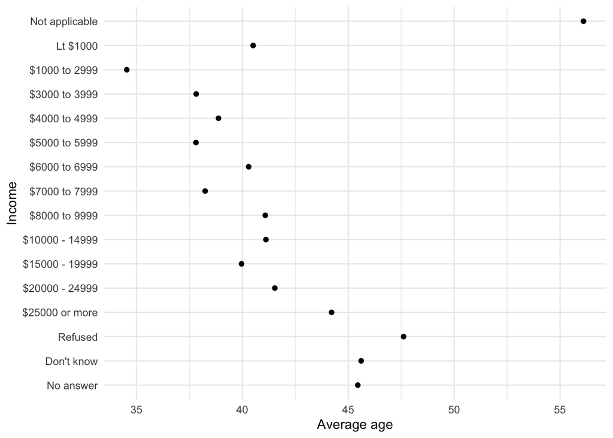

```r
# Exercise 12 - Do you think using fct_reorder makes sense here? Why/why not?

# Let's plot the same graph without fct_reorder for comparison.

rincome_summary %>%
  ggplot(aes(age, rincome)) +
  geom_point() +
    xlab("Average age") +
    ylab("Income") +
    theme_minimal()
```

The plot that does not use the factor reorder is more intuitive and easy to read, since it follows a logical income level on axis Y, making it easier to understand variations in the variable age as the income increases. The variable ‘rincome’ has has an intuitive ans intrisic order, so using factor reorder is not valuable here.

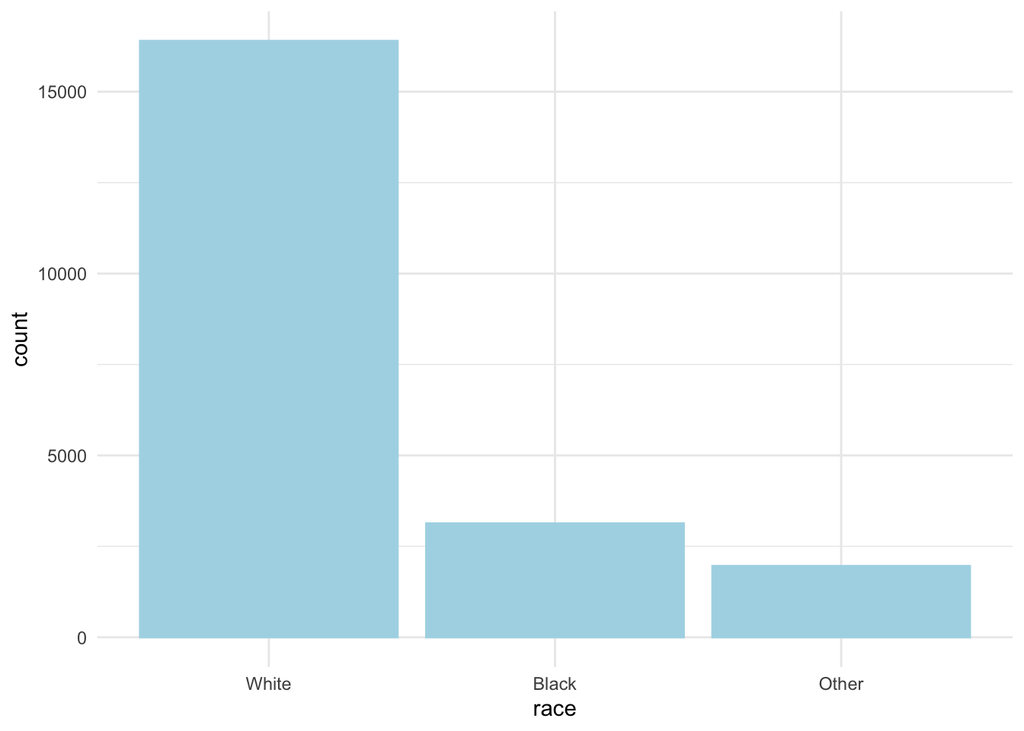

```r
# Exercise 13 - create a bar plot using fct_infreq to reorder levels of the race variable?

gss_cat %>%
  mutate(race = fct_infreq(race)) %>%
  ggplot(aes(race)) +
    geom_bar(col = "lightblue", fill = "lightblue") +
    theme_minimal()
```

Exercise 14 - In the exercises we learned that it is not sensible to reorder factor variables that have a principled order, such as income. Are the remaining categorical variables in gss_cat in a principled order?

We have looked at income which has an intuitive order, the other categorical features in gss_cat are: ‘marital’ (relationship status), ‘race’ (race), ‘partyid’ (party affiliation), ‘relig’ (religion), and ‘denom’ (denomination), which do not have a principled or logical order. They could be organized just like the exercises above, by using frequency, or any other pattern of interest.

#### Modifying factor levels

```r
# Exercise 15 - Use ’fct_recode()` to recode “Don’t know” and “No answer” to NA.
# fct_recode(x, NULL = "Old value").

gss_cat %>%
  mutate(partyid = fct_recode(partyid,
    NULL = "No answer",
    NULL = "Don't know"
  )) %>%
  count(partyid)
```

```
## # A tibble: 9 × 2
##   partyid                n
##   <fct>              <int>
## 1 Other party          393
## 2 Strong republican   2314
## 3 Not str republican  3032
## 4 Ind,near rep        1791
## 5 Independent         4119
## 6 Ind,near dem        2499
## 7 Not str democrat    3690
## 8 Strong democrat     3490
## 9 <NA>                 155
```

```r
# fct_collapse() is similar to fct_recode but takes a vector of values as an argument.

# Exercise 16 - Can you use fct_collapse() to create three levels for income: “0 to $10,000”, “$10,000 to $20,000”, and NA for the remaining levels?

# The exercise specifies three levels 0-10k, 10-20k, NA. But there are two levels (20-25k) and (25k or more) not included, that could be a in fourth category or be included in a modified second, instead of 10-20k > 10 or more.

gss_cat %>%
  mutate(rincome = fct_collapse(rincome,
    "0 to $10,000" = c("Lt $1000",
                       "$1000 to 2999",
                       "$3000 to 3999",
                       "$4000 to 4999",
                       "$5000 to 5999",
                       "$6000 to 6999",
                       "$7000 to 7999",
                       "$8000 to 9999"),
    "$10,000 to $20,000" = c("$10000 - 14999",
                             "$15000 - 19999",
                             "$20000 - 24999",
                             "$25000 or more"),
    NULL = c("Don't know",
             "No answer",
             "Not applicable",
             "Refused")
    )) %>%
  count(rincome)
```

```
## # A tibble: 3 × 2
##   rincome                n
##   <fct>              <int>
## 1 NULL                8468
## 2 $10,000 to $20,000 10862
## 3 0 to $10,000        2153
```

```r
# Exercise 17 - use fct_lump() to collapse the marital variable

gss_cat %>%
  mutate(marital = fct_lump(marital)) %>%
  count(marital, sort = TRUE)
```

```
## # A tibble: 4 × 2
##   marital           n
##   <fct>         <int>
## 1 Married       10117
## 2 Never married  5416
## 3 Divorced       3383
## 4 Other          2567
```

```r
# the default was helpful, not being necessary to specify an n to set the number of factors to be preserved.
```

### Creating tables

```r
gss_sample <- gss_cat[sample(nrow(gss_cat), 10),] # Takes a random sample of 10 observations from the data

# Exercise 18 - create a formatted summary table using the kable package

# kable() generates nicely formatted tables from matrices or data frames in R Markdown
kable(gss_sample)
```

| year | marital | age | race | rincome | partyid | relig | denom | tvhours |
| --- | --- | --- | --- | --- | --- | --- | --- | --- |
| 2006 | Married | 73 | White | Not applicable | Strong republican | Protestant | United methodist | NA |
| 2002 | Never married | 23 | White | Not applicable | Independent | None | Not applicable | NA |
| 2010 | Never married | 21 | White | $15000 - 19999 | Ind,near dem | Protestant | Other | 1 |
| 2006 | Married | 32 | White | $25000 or more | Not str republican | Protestant | United methodist | NA |
| 2006 | Married | 49 | White | $20000 - 24999 | Not str republican | Protestant | No denomination | 2 |
| 2014 | Never married | 37 | White | $10000 - 14999 | Strong democrat | None | Not applicable | 1 |
| 2006 | Married | 58 | White | Not applicable | Independent | Catholic | Not applicable | 2 |
| 2008 | Never married | 25 | Black | Refused | Strong democrat | Protestant | Baptist-dk which | 2 |
| 2002 | Married | 22 | White | No answer | Ind,near dem | Protestant | United methodist | NA |
| 2004 | Married | 29 | Other | Refused | Independent | Catholic | Not applicable | NA |

```r
# Exercise 19 - try using select() alongside kable() to display only the variables “year”, “age”, “race” and “rincome”.

select(gss_sample, year, age, race, rincome) %>%
  kable()
```

| year | age | race | rincome |
| --- | --- | --- | --- |
| 2006 | 73 | White | Not applicable |
| 2002 | 23 | White | Not applicable |
| 2010 | 21 | White | $15000 - 19999 |
| 2006 | 32 | White | $25000 or more |
| 2006 | 49 | White | $20000 - 24999 |
| 2014 | 37 | White | $10000 - 14999 |
| 2006 | 58 | White | Not applicable |
| 2008 | 25 | Black | Refused |
| 2002 | 22 | White | No answer |
| 2004 | 29 | Other | Refused |

```r
# Exercise 20 - Try changing the font size of the table.

kable(gss_sample) %>%
  kable_styling(font_size = 20)
```

| year | marital | age | race | rincome | partyid | relig | denom | tvhours |
| --- | --- | --- | --- | --- | --- | --- | --- | --- |
| 2006 | Married | 73 | White | Not applicable | Strong republican | Protestant | United methodist | NA |
| 2002 | Never married | 23 | White | Not applicable | Independent | None | Not applicable | NA |
| 2010 | Never married | 21 | White | $15000 - 19999 | Ind,near dem | Protestant | Other | 1 |
| 2006 | Married | 32 | White | $25000 or more | Not str republican | Protestant | United methodist | NA |
| 2006 | Married | 49 | White | $20000 - 24999 | Not str republican | Protestant | No denomination | 2 |
| 2014 | Never married | 37 | White | $10000 - 14999 | Strong democrat | None | Not applicable | 1 |
| 2006 | Married | 58 | White | Not applicable | Independent | Catholic | Not applicable | 2 |
| 2008 | Never married | 25 | Black | Refused | Strong democrat | Protestant | Baptist-dk which | 2 |
| 2002 | Married | 22 | White | No answer | Ind,near dem | Protestant | United methodist | NA |
| 2004 | Married | 29 | Other | Refused | Independent | Catholic | Not applicable | NA |

```r
kable(gss_sample) %>%
  kable_styling(font_size = 5)
```

| year | marital | age | race | rincome | partyid | relig | denom | tvhours |
| --- | --- | --- | --- | --- | --- | --- | --- | --- |
| 2006 | Married | 73 | White | Not applicable | Strong republican | Protestant | United methodist | NA |
| 2002 | Never married | 23 | White | Not applicable | Independent | None | Not applicable | NA |
| 2010 | Never married | 21 | White | $15000 - 19999 | Ind,near dem | Protestant | Other | 1 |
| 2006 | Married | 32 | White | $25000 or more | Not str republican | Protestant | United methodist | NA |
| 2006 | Married | 49 | White | $20000 - 24999 | Not str republican | Protestant | No denomination | 2 |
| 2014 | Never married | 37 | White | $10000 - 14999 | Strong democrat | None | Not applicable | 1 |
| 2006 | Married | 58 | White | Not applicable | Independent | Catholic | Not applicable | 2 |
| 2008 | Never married | 25 | Black | Refused | Strong democrat | Protestant | Baptist-dk which | 2 |
| 2002 | Married | 22 | White | No answer | Ind,near dem | Protestant | United methodist | NA |
| 2004 | Married | 29 | Other | Refused | Independent | Catholic | Not applicable | NA |

```r
# Exercise 21 - Try out using one or more of the themes.

# The kableExtra package also comes with different themes:
# kable_paper
# kable_classic
# kable_classic_2
# kable_minimal
# kable_material
# kable_material_dark

kable(gss_sample) %>%
  kable_styling(font_size = 20) %>%
  kable_classic_2()
```

| year | marital | age | race | rincome | partyid | relig | denom | tvhours |
| --- | --- | --- | --- | --- | --- | --- | --- | --- |
| 2006 | Married | 73 | White | Not applicable | Strong republican | Protestant | United methodist | NA |
| 2002 | Never married | 23 | White | Not applicable | Independent | None | Not applicable | NA |
| 2010 | Never married | 21 | White | $15000 - 19999 | Ind,near dem | Protestant | Other | 1 |
| 2006 | Married | 32 | White | $25000 or more | Not str republican | Protestant | United methodist | NA |
| 2006 | Married | 49 | White | $20000 - 24999 | Not str republican | Protestant | No denomination | 2 |
| 2014 | Never married | 37 | White | $10000 - 14999 | Strong democrat | None | Not applicable | 1 |
| 2006 | Married | 58 | White | Not applicable | Independent | Catholic | Not applicable | 2 |
| 2008 | Never married | 25 | Black | Refused | Strong democrat | Protestant | Baptist-dk which | 2 |
| 2002 | Married | 22 | White | No answer | Ind,near dem | Protestant | United methodist | NA |
| 2004 | Married | 29 | Other | Refused | Independent | Catholic | Not applicable | NA |

```r
kable(gss_sample) %>%
  kable_styling(font_size = 20) %>%
  kable_minimal()
```

| year | marital | age | race | rincome | partyid | relig | denom | tvhours |
| --- | --- | --- | --- | --- | --- | --- | --- | --- |
| 2006 | Married | 73 | White | Not applicable | Strong republican | Protestant | United methodist | NA |
| 2002 | Never married | 23 | White | Not applicable | Independent | None | Not applicable | NA |
| 2010 | Never married | 21 | White | $15000 - 19999 | Ind,near dem | Protestant | Other | 1 |
| 2006 | Married | 32 | White | $25000 or more | Not str republican | Protestant | United methodist | NA |
| 2006 | Married | 49 | White | $20000 - 24999 | Not str republican | Protestant | No denomination | 2 |
| 2014 | Never married | 37 | White | $10000 - 14999 | Strong democrat | None | Not applicable | 1 |
| 2006 | Married | 58 | White | Not applicable | Independent | Catholic | Not applicable | 2 |
| 2008 | Never married | 25 | Black | Refused | Strong democrat | Protestant | Baptist-dk which | 2 |
| 2002 | Married | 22 | White | No answer | Ind,near dem | Protestant | United methodist | NA |
| 2004 | Married | 29 | Other | Refused | Independent | Catholic | Not applicable | NA |

```r
kable(gss_sample) %>%
  kable_styling(font_size = 20) %>%
  kable_material_dark()
```

| year | marital | age | race | rincome | partyid | relig | denom | tvhours |
| --- | --- | --- | --- | --- | --- | --- | --- | --- |
| 2006 | Married | 73 | White | Not applicable | Strong republican | Protestant | United methodist | NA |
| 2002 | Never married | 23 | White | Not applicable | Independent | None | Not applicable | NA |
| 2010 | Never married | 21 | White | $15000 - 19999 | Ind,near dem | Protestant | Other | 1 |
| 2006 | Married | 32 | White | $25000 or more | Not str republican | Protestant | United methodist | NA |
| 2006 | Married | 49 | White | $20000 - 24999 | Not str republican | Protestant | No denomination | 2 |
| 2014 | Never married | 37 | White | $10000 - 14999 | Strong democrat | None | Not applicable | 1 |
| 2006 | Married | 58 | White | Not applicable | Independent | Catholic | Not applicable | 2 |
| 2008 | Never married | 25 | Black | Refused | Strong democrat | Protestant | Baptist-dk which | 2 |
| 2002 | Married | 22 | White | No answer | Ind,near dem | Protestant | United methodist | NA |
| 2004 | Married | 29 | Other | Refused | Independent | Catholic | Not applicable | NA |